# STAT 689 Homework 12

## Rohan Tiwari

Consult the directory OPEN Data, and get the files OPEN_sim.csv and OPEN_README.pdf. The README file will tell you about the data, so look at it carefully for definitions. You will be comparing different estimates of the percentage of calories from protein (%CFP) for women.

```r
opendata = read.csv("OPEN_sim_2019.csv")
head(opendata)
```

```
##   ID Meas Age   BMI Truth   FFQ Recall   Bio
## 1  1    1  49 31.29 27.89 36.54  30.52 26.27
## 2  1    2  49 31.29 27.89 46.45  38.80 20.46
## 3  2    1  62 20.96 23.07 26.53  25.24 21.94
## 4  2    2  62 20.96 23.07 20.87  16.25 17.61
## 5  3    1  46 19.09 26.53 23.53  23.30 29.62
## 6  3    2  46 19.09 26.53 27.61  23.07 33.06
```

### 1. Compare the true %CFP to the average %CFP estimated by each instrument (AvgFFQ, AvgRecall, and AvgBio). Make a boxplot comparing the three instruments, where you take their differences with the truth. Describe why you think one of the instruments is best.

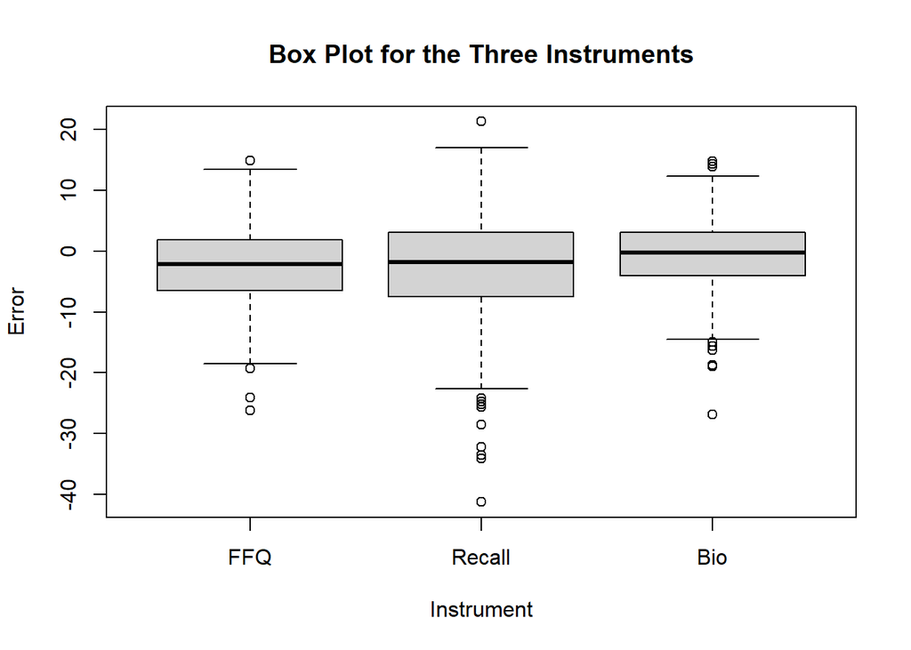

```r
truth = opendata$Truth
ffq = opendata$FFQ
recall = opendata$Recall
bio = opendata$Bio

ffq_error = truth - ffq
recall_error = truth - recall
bio_error = truth - bio

boxplot(ffq_error, recall_error, bio_error
        , names = c("FFQ", "Recall", "Bio")
        , xlab="Instrument"
        , ylab="Error"
        , main="Box Plot for the Three Instruments"
        )
```

Bio seems to be the best instrument because it has the lowest variance which makes it more reliable compared to other instruments.

### 2. Fit a random intercept spline model with the response being the biomarker (Bio in the data set), and the predictors being the FFQ and the 24HR, both modeled as splines.

```r
library(gamm4)
fit_gamm4 = gamm4(bio ~ s(ffq) + s(recall), random= ~(1|ID), data=opendata)
```

### 2a. Display the summaries of the fit. Tell us which, if any, is a statistically significant predictor of the biomarker.

```r
summary(fit_gamm4$gam)
```

```
##
## Family: gaussian
## Link function: identity
##
## Formula:
## bio ~ s(ffq) + s(recall)
##
## Parametric coefficients:
##             Estimate Std. Error t value Pr(>|t|)
## (Intercept)  28.4184     0.3795   74.89   <2e-16 ***
## ---
## Signif. codes:  0 '***' 0.001 '**' 0.01 '*' 0.05 '.' 0.1 ' ' 1
##
## Approximate significance of smooth terms:
##             edf Ref.df      F  p-value
## s(ffq)    1.000  1.000 15.680 8.77e-05 ***
## s(recall) 1.806  1.806  1.164    0.214
## ---
## Signif. codes:  0 '***' 0.001 '**' 0.01 '*' 0.05 '.' 0.1 ' ' 1
##
## R-sq.(adj) =  0.0658
## lmer.REML = 3003.5  Scale est. = 37.946    n = 446
```

Based on the summaries, it looks like s(ffq) is statistically significant predictor of bio.

### 3. What are the between and within standard deviations of the fit? This is a single fit.

```r
summary(fit_gamm4$mer)
```

```
## Linear mixed model fit by REML ['lmerMod']
##
## REML criterion at convergence: 3003.5
##
## Scaled residuals:
##     Min      1Q  Median      3Q     Max
## -2.1065 -0.6350 -0.0469  0.4642  3.2592
##
## Random effects:
##  Groups   Name        Variance Std.Dev.
##  ID       (Intercept) 13.142   3.625
##  Xr.0     s(recall)    8.884   2.981
##  Xr       s(ffq)       0.000   0.000
##  Residual             37.946   6.160
## Number of obs: 446, groups:  ID, 223; Xr.0, 8; Xr, 8
##
## Fixed effects:
##               Estimate Std. Error t value
## X(Intercept)   28.4184     0.3795  74.886
## Xs(ffq)Fx1      1.4516     0.3666   3.960
## Xs(recall)Fx1   0.6381     0.7733   0.825
##
## Correlation of Fixed Effects:
##             X(Int) Xs(f)F1
## Xs(ffq)Fx1   0.000
## Xs(rcll)Fx1  0.000 -0.082
```

the between group std.dev is 3.625 and within group std.dev is 6.160.

### 4. Display the fitted curves for both the FFQ and the 24HR in one graph. I suggest that you set up a grid of %CFP as your x-values and use that grid when predicting responses from your model.

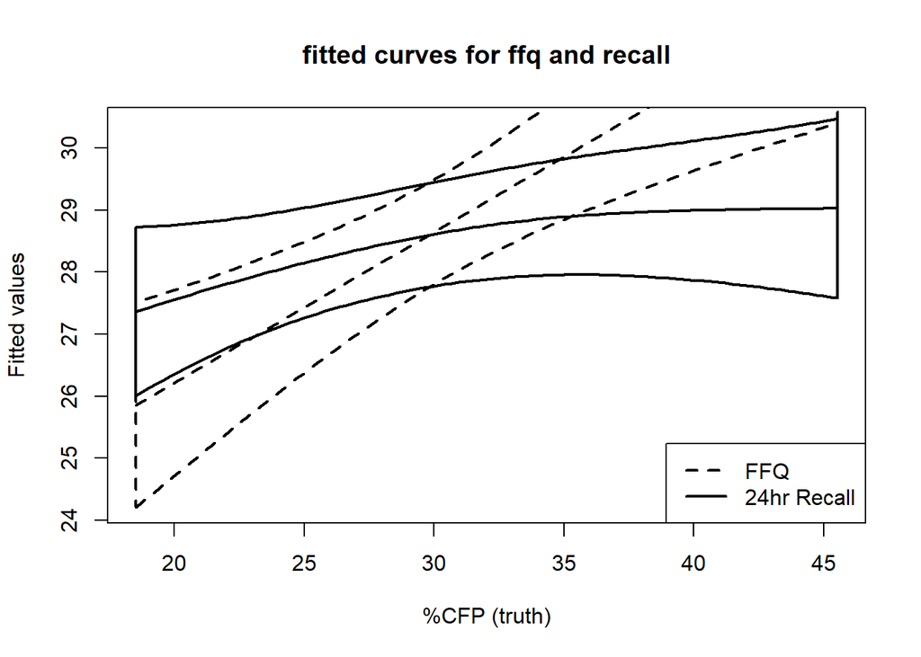

```r
ng <- 101

#vary ffq
cfpg <- seq(from=min(opendata$Truth), to=max(opendata$Truth),length=ng)
#fix recall to average
recallg = rep(mean(opendata$Recall), ng)

newDF <- data.frame(ffq  = cfpg, recall = recallg)
predObj_one <- predict(fit_gamm4$gam, newDF, se=T)
lowdirg_one <- predObj_one$fit - qnorm(0.975)*predObj_one$se.fit
uppdirg_one <- predObj_one$fit + qnorm(0.975)*predObj_one$se.fit

plot(0,type="n",xlab = "%CFP (truth)",
     ylab = "Fitted values",main = "fitted curves for ffq and recall",
     xlim = c(min(cfpg),max(cfpg)),
     ylim = c(min(lowdirg_one),max(lowdirg_one)))
polygon(c(cfpg, rev(cfpg)), c(lowdirg_one, rev(uppdirg_one))
         , border=T
         , lty=2
         , lwd=2
        )
lines(cfpg, predObj_one$fit, col="black", lty=2, lwd=2)

#vary recall
recallg <- seq(from=min(opendata$Truth), to=max(opendata$Truth),length=ng)
#fix ffq to average
ffqg = rep(mean(opendata$FFQ), ng)
newDataDF_two <- data.frame(ffq  = ffqg, recall = recallg)
predObj_two <- predict(fit_gamm4$gam, newDataDF_two, se=T)
lowdirg_two <- predObj_two$fit - qnorm(0.975)*predObj_two$se.fit
uppdirg_two <- predObj_two$fit + qnorm(0.975)*predObj_two$se.fit
polygon(c(cfpg, rev(cfpg)), c(lowdirg_two, rev(uppdirg_two))
        , border=T
        , lwd=2
)
lines(recallg, predObj_two$fit, col="black", lwd=2)
legend("bottomright", c("FFQ", "24hr Recall"), lty=c(2,1), lwd=c(2,2))
```

### 5. In the model from question (2), add Age and BMI as linear predictors. Which are these two are statistically significant?

```r
fit_gamm4_1 = gamm4(bio ~ s(ffq) + s(recall) + Age + BMI, random= ~(1|ID), data=opendata)
summary(fit_gamm4_1$gam)
```

```
##
## Family: gaussian
## Link function: identity
##
## Formula:
## bio ~ s(ffq) + s(recall) + Age + BMI
##
## Parametric coefficients:
##             Estimate Std. Error t value Pr(>|t|)
## (Intercept) 32.09671    3.15621  10.169   <2e-16 ***
## Age          0.01403    0.04823   0.291   0.7713
## BMI         -0.19693    0.07622  -2.584   0.0101 *
## ---
## Signif. codes:  0 '***' 0.001 '**' 0.01 '*' 0.05 '.' 0.1 ' ' 1
##
## Approximate significance of smooth terms:
##             edf Ref.df     F  p-value
## s(ffq)    1.000  1.000 14.78 0.000139 ***
## s(recall) 1.992  1.992  1.97 0.124723
## ---
## Signif. codes:  0 '***' 0.001 '**' 0.01 '*' 0.05 '.' 0.1 ' ' 1
##
## R-sq.(adj) =  0.0804
## lmer.REML = 3004.2  Scale est. = 37.974    n = 446
```

s(ffq) and BMI are statistically significant.

### 6. In these data, see if the biomarker (not the truth) needs a random function model or a random intercept model.

### 6a. Of course, you can test this in gamm4.

```r
# Now run the random functions analysis, but
# in gamm4::gamm4
#On canvas, professor said "Pick either the recall or the ffq as the covariate: not both".
# we will pick ffq
fit_gamm4_ffq = gamm4(bio ~ s(ffq), random= ~(1|ID), data=opendata)
fit_gamm4_rf = gamm4::gamm4(bio ~
               + s(I(ffq), k=7) + s(I(ffq), ID, k=5, xt=list(bs="cr"))
               ,data=opendata)
print(summary(fit_gamm4_rf$gam)$s.table, signif.stars = FALSE)
```

```
##                   edf   Ref.df          F      p-value
## s(I(ffq))    1.000000 1.000000 28.1543843 1.775776e-07
## s(I(ffq),ID) 2.181799 2.181799  0.4630131 4.756832e-01
```

```r
# In gamm4:gamm4, test whether the random functions
# are needed
print(anova(fit_gamm4_ffq$mer, fit_gamm4_rf$mer), signif.stars = FALSE)
```

```
## refitting model(s) with ML (instead of REML)
```

```
## Data: NULL
## Models:
## fit_gamm4_ffq$mer: NULL
## fit_gamm4_rf$mer: NULL
##                   npar    AIC    BIC  logLik deviance Chisq Df Pr(>Chisq)
## fit_gamm4_ffq$mer    5 3015.2 3035.7 -1502.6   3005.2
## fit_gamm4_rf$mer     6 3033.2 3057.8 -1510.6   3021.2     0  1          1
```

Based on the anova results, we do not need a random function for these data

### 6b. However, let’s pretend you need to convince people that this is true. How about some plots?

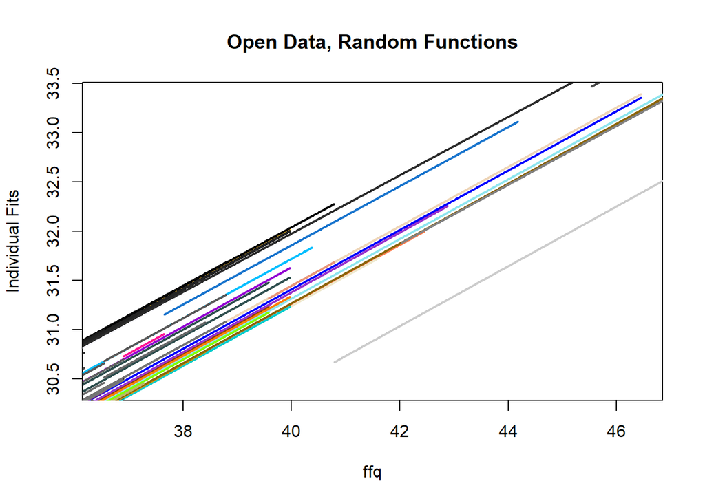

```r
###################################################
# Plot individual random functions
###################################################
# pdf("Indiana_Random_Function_Plots.pdf")
# jpeg("Indiana_Random_Function_Plots.jpg")
random_Function_Plots = fit_gamm4_rf$gam$fitted.values
n = length(unique(opendata$ID))
ccc = colors()
for (ii in 1:n){
  ffq1 = ffq[opendata$ID == ii]
  random_Function_Plots1 = fit_gamm4_rf$gam$fitted.values[opendata$ID == ii]
  if (ii == 1){
    plot(ffq1,random_Function_Plots1,type="n",xlab="ffq",ylab="Individual Fits",
         main="Open Data, Random Functions")
  }
lines(ffq1,random_Function_Plots1,col=ccc[20+ii],lwd=2)
}
```